# STAT 206 Lab 1

**Due Monday, October 10, 5:00 PM**

*General instructions for labs*: You are encouraged to work in pairs to complete the lab. Labs must be completed as an R Markdown file. Be sure to include your lab partner (if you have one) and your own name in the file. Give the commands to answer each question in its own code block, which will also produce plots that will be automatically embedded in the output file. Each answer must be supported by written statements as well as any code used.

*Agenda*: Manipulating data objects; using built-in functions, doing numerical calculations, and basic plots; reinforcing core probabilistic ideas.

## Background

The exponential distribution is defined by its cumulative distribution function

$$F(x) = 1-e^{-\lambda x}$$

The R function `rexp` generates random variables with an exponential distribution.

```
rexp(n=10, rate=5)
```

produces 10 exponentially-distributed numbers with rate ($\lambda$) of 5. If the second argument is omitted, the default rate is 1; this is the ``standard exponential distribution’’.

## Part I

1. Generate 200 random values from the standard exponential distribution and store them in a vector `exp.draws.1`. Find the mean and standard deviation of `exp.draws.1`.

```r
exp.draws.1 = rexp(200) #This generates 200 random variables and stores them to the vector object exp.draws.1

mean(exp.draws.1) #This is the mean of the vector object exp.draws.1
```

```
## [1] 0.9675748
```

```r
sd(exp.draws.1) #This is the standard deviation of the vector object exp.draws.1
```

```
## [1] 0.9163941
```

2. Repeat, but change the rate to 0.1, 0.5, 5 and 10, storing the results in vectors called `exp.draws.0.1`, `exp.draws.0.5`, `exp.draws.5` and `exp.draws.10`.

```r
exp.draws.0.1 = rexp(200, .1) #This generates 200 random variables and stores them to the vector object exp.draws.0.1

mean(exp.draws.0.1) #This is the mean of the vector object exp.draws.0.1
```

```
## [1] 8.8877
```

```r
sd(exp.draws.0.1) #This is the standard deviation of the vector object exp.draws.0.1
```

```
## [1] 9.22102
```

```r
exp.draws.0.5 = rexp(200, .5) #This generates 200 random variables and stores them to the vector object exp.draws.0.5

mean(exp.draws.0.5) #This is the mean of the vector object exp.draws.0.5
```

```
## [1] 2.007812
```

```r
sd(exp.draws.0.5) #This is the standard deviation of the vector object exp.draws.0.5
```

```
## [1] 2.312052
```

```r
exp.draws.5 = rexp(200, 5) #This generates 200 random variables and stores them to the vector object exp.draws.5

mean(exp.draws.5) #This is the mean of the vector object exp.draws.5
```

```
## [1] 0.1959651
```

```r
sd(exp.draws.5) #This is the standard deviation of the vector object exp.draws.0.5
```

```
## [1] 0.1891623
```

```r
exp.draws.10 = rexp(200, 10) #This generates 200 random variables and stores them to the vector object exp.draws.10

mean(exp.draws.10) #This is the mean of the vector object exp.draws.10
```

```
## [1] 0.101884
```

```r
sd(exp.draws.10) #This is the standard deviation of the vector object exp.draws.10
```

```
## [1] 0.1011687
```

3. The function `plot()` is the generic function in R for the visual display of data. `hist()` is a function that takes in and bins data as a side effect. To use this function, we must first specify what we’d like to plot.
   1. Use the `hist()` function to produce a histogram of your standard exponential distribution.

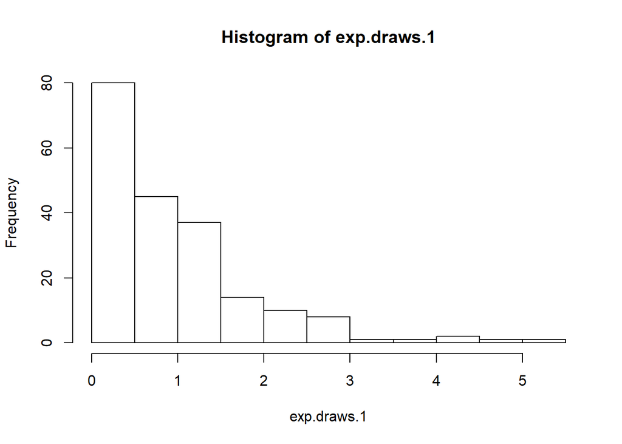

   ```r
     hist(exp.draws.1) # calling the hist function and passing exp.draws1 as the argument
   ```

   2. Use `plot()` with this vector to display the random values from your standard distribution in order.

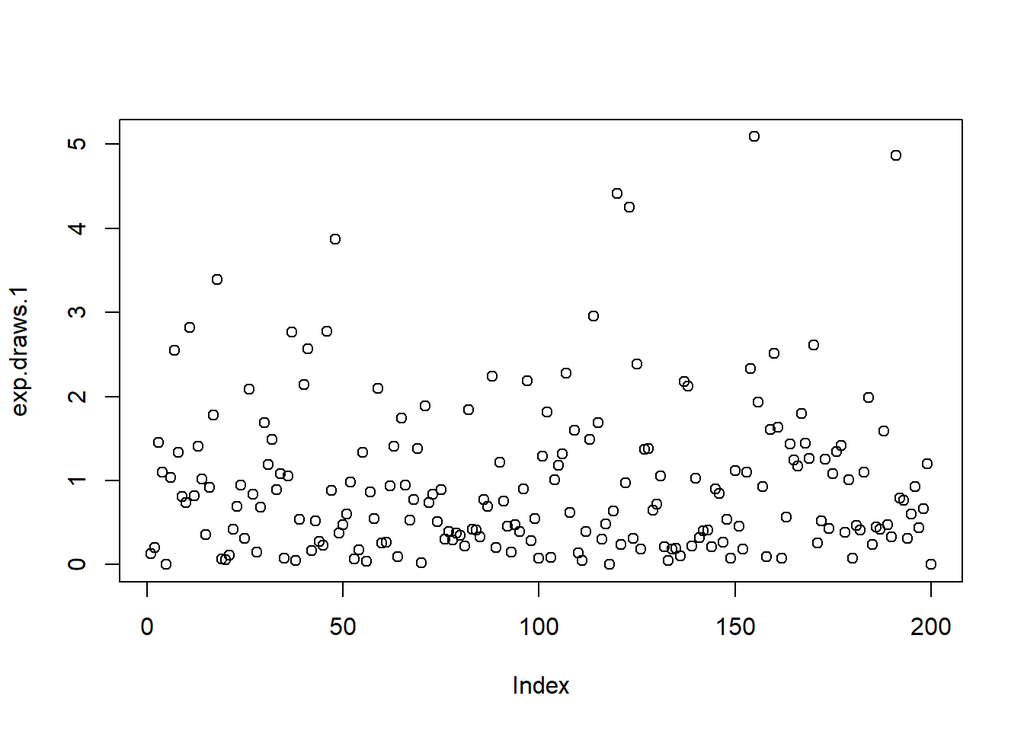

   ```r
   plot(exp.draws.1) #creating a scatter plot for the same data as above
   ```

   3. Now, use `plot()` with two arguments – any two of your other stored random value vectors – to create a scatterplot of the two vectors against each other.

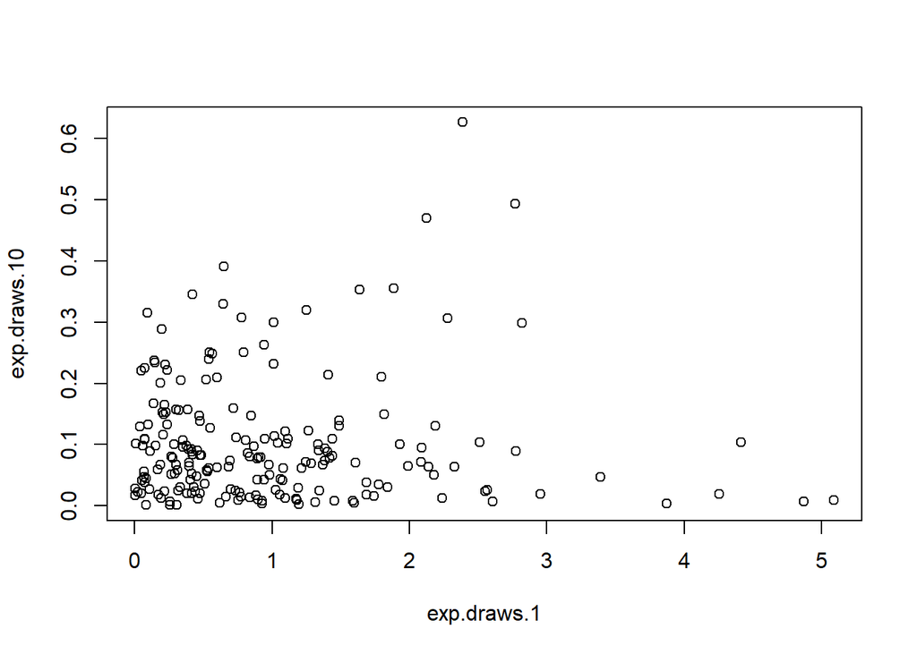

   ```r
   plot(exp.draws.1, exp.draws.10) # calling the plot fuction but passing in two different vectors as arguments
   ```

```r
# below is a object vector to store the means of the vectors in order
five_means = c(mean(exp.draws.1), mean(exp.draws.0.1), mean(exp.draws.0.5), mean(exp.draws.5), mean(exp.draws.10))

#below is a object vector to store the rates of the vectors in order of creation
five_rates = c(1, 0.1, 0.5, 5, 10)
five_rates
```

```
## [1]  1.0  0.1  0.5  5.0 10.0
```

```r
#below is an object vector to store the standard deviations of the vectors in order
five_sd = c(sd(exp.draws.1), sd(exp.draws.0.1), sd(exp.draws.0.5), sd(exp.draws.5), sd(exp.draws.10))
five_sd
```

```
## [1] 0.9163941 9.2210199 2.3120517 0.1891623 0.1011687
```

[output not shown]

For each plot, explain in words what’s going on.